# Rankcluster: An R Package for Clustering Multivariate Partial Rankings

Finally, the variability of estimation of the model parameters can be achieved by means of the distances between the final estimate and the current value at each step of the SEM-Gibbs algorithm (refer to (Jacques and Biernacki 2012) for accurate definitions of these distances). These distances are available in the slots `distanceProp, distancePi, distanceMu` of the output `res[2]`. The standard deviation of these distances can be used for instance as an indicator of estimation variability. For instance, the standard deviation of the Kendall distance (Marden 1995) between the final esitimate of the mode and its current value at each step of the SEM-Gibbs algorithm is for cluster 2: 0.52 for the UEFA coefficients rankings and 0.43 for Premier League rankings. Similarly, the standard deviation of the scale estimate is for cluster 2 about 0.002 for both the UEFA coefficients and the Premier League rankings. Note that these variabilities are relatively small, due to the low overlapping of the two clusters (scale coefficients are quite high). In a similar way, the slot `distanceZ` illustrates the convergence of the SEM-Gibbs algorithm by given the Rand index (Rand 1971) between the final partition and the current partition at each SEM-Gibbs iteration (Figure 4).

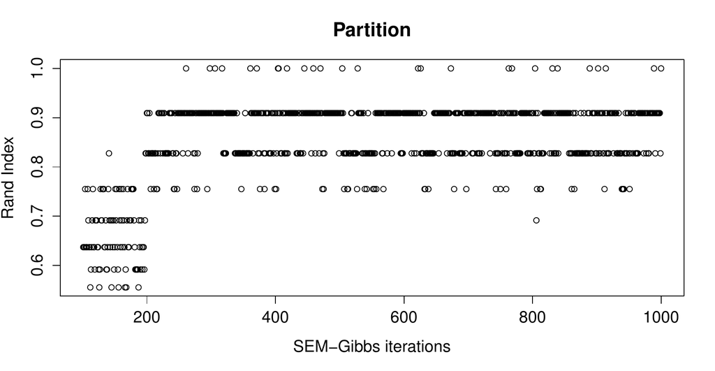

Figure 4: Evolution of the partition along with the SEM-Gibbs iterations: values of the Rand index between current and final partitions.

## 6 Conclusion

*Rankcluster* is the first R package dedicated to ranking data that allows modeling and cluster analysis for multivariate partial ranking data. Available on the CRAN website, this package is simple to use with its main function, `rankclust()`, having only one mandatory argument, the ranking dataset. By default a single homogeneous multivariate ISR model is fitted to the data, and specifying the number of desired clusters leads to perform a cluster analysis, with selection of the number of clusters if several numbers are given. The analysis of two real datasets presented in this paper illustrates the possibilities of the package, and also constitutes a user guide for practitioners.

### 6.1 CRAN packages used

Rankcluster, pmr, RMallow

### 6.2 CRAN Task Views implied by cited packages

C. Biernacki, G. Celeux and G. Govaert. Assessing a mixture model for clustering with the integrated completed likelihood. *IEEE Transactions on Pattern Analysis and Machine Intelligence*, 22(4): 719–725, 2000.

C. Biernacki and J. Jacques. A generative model for rank data based on insertion sort algorithm. *Computational Statistics & Data Analysis*, 58: 162–176, 2013.

G. Celeux and J. Diebolt. The SEM algorithm: A probabilistic teacher algorithm derived from the EM algorithm for the mixture problem. *Computational Statistics Quarterly*, 2(1): 73–82, 1985.

A. P. Dempster, N. M. Laird and D. B. Rubin. Maximum likelihood from incomplete data via the EM algorithm. *Journal of the Royal Statistical Society. Series B. Methodological*, 39(1): 1–38, 1977. With discussion.

M. A. Fligner and J. S. Verducci. Distance based ranking models. *Journal of the Royal Statistical Society. Series B. Methodological*, 48(3): 359–369, 1986.

A. Geman and D. Geman. Stochastic relaxation, Gibbs distributions and the Bayesian restoration of images. *IEEE Transactions on Pattern Analysis and Matching Intelligence*, 6: 721–741, 1984.

I. C. Gormley and T. B. Murphy. A mixture of experts model for rank data with applications in election studies. *Annals of Applied Statistics*, 2(4): 1452–1477, 2008.

E. Gregory. *RMallow: Fit multi-modal mallows’ models to ranking data.* 2012. URL http://CRAN.R-project.org/package=RMallow. R package version 1.0.

J. Jacques and C. Biernacki. Model-based clustering for multivariate partial ranking data. 8113. Inria Research Report. 2012.

P. H. Lee and P. L. H. Yu. An R package for analyzing and modeling ranking data. *BMC Medical Research Methodology*, 13(65): 1–11, 2013.

J. I. Marden. *Analyzing and modeling rank data.* London: Chapman & Hall, 1995.

T. B. Murphy and D. Martin. Mixtures of distance-based models for ranking data. *Comput. Statist. Data Anal.*, 41(3-4): 645–655, 2003.

W. M. Rand. Objective criteria for the evaluation of clustering methods. *Journal of the American Statistical Association*, 55: 846–850, 1971.

G. Schwarz. Estimating the dimension of a model. *The Annals of Statistics*, 6(2): 461–464, 1978.